# Using DGIdb to aid in hypothesis generation for the analysis of the underlying genetics behind resistant hypertension

Clementina Strozek - cas9788

## Introduction

In this project DGIdb Graphl QL software was utilized to decipher known drug gene interactions for Hydrochlorothiazide (HCTZ), a drug to treat hypertension through inhibition of sodium cotransporters in the tube of the kidneys. This database's utility aids in annotation of genes of interest for research purposes, but also can be helpful in hypothesis generation. DGIdb API uses GraphQL which allows for the interaction of a server or database from a programming language. The GraphQL requires a query which details inputs that will be sent out in a request. This quickly and efficiently retrieves data from the server aiding in gene annotations for projects and hypothesis generation. In this study DGIdb is used initially to explore its utility and use it for hypothesis generation. Based on the interactions of genes with HCTZ this raised the question whether these genes are differentially expressed for individuals experiencing resistant hypertension (hypertension that is not alleviated with the treatment of three or more anti-hypertensive drugs). Using publicly available data from NCBI GEO (Series: GSE236442), from the study : Joint Analysis of Multiple Omics to Describe the Biological Characteristics of Resistant Hypertension conducted at at Shandong University of Traditional Chinese Medicine on Normotensive, Hypertensive, and Anti-hypertensive resistives, the objective was to determine differential gene expression between hypertensive patients. The raw sequencing data was downloaded from SRA (Project: PRJNA990810) and a count matrix was produced using tools avalible on the NYU Greene Cluster HPC. Differential gene expression was done using DESeq2 in R. The significant genes were annotated using Gene Ontology (GO) databases and queried through DGIdb again to determine other drug interactions with the gene.

## Materials and Methods

```r
install.packages("IRdisplay")
```

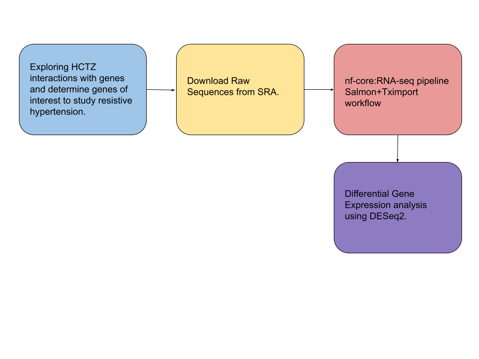

```r
library(IRdisplay)

display_png(file = "Methodology.png")
```

Above is the workflow followed starting from hypothesis generation, followed by obtaining sequencing data and processing for differential gene expression.

### DGIDB Implementation

```r
# install.packages("reticulate")
library("reticulate")
```

The utility of the GraphQL for users interested in drug gene interactions, is that it can quickly obtain data for researchers to collect efficiently and store in their markdown files for programming. Given that the amount of data is growing exponentially GraphQL can efficiently concatenate all the data and be able to give researchers useful information on what has been discovered, which can be helpful for hypothesis generation or stregthening original research with observations found in public databases.

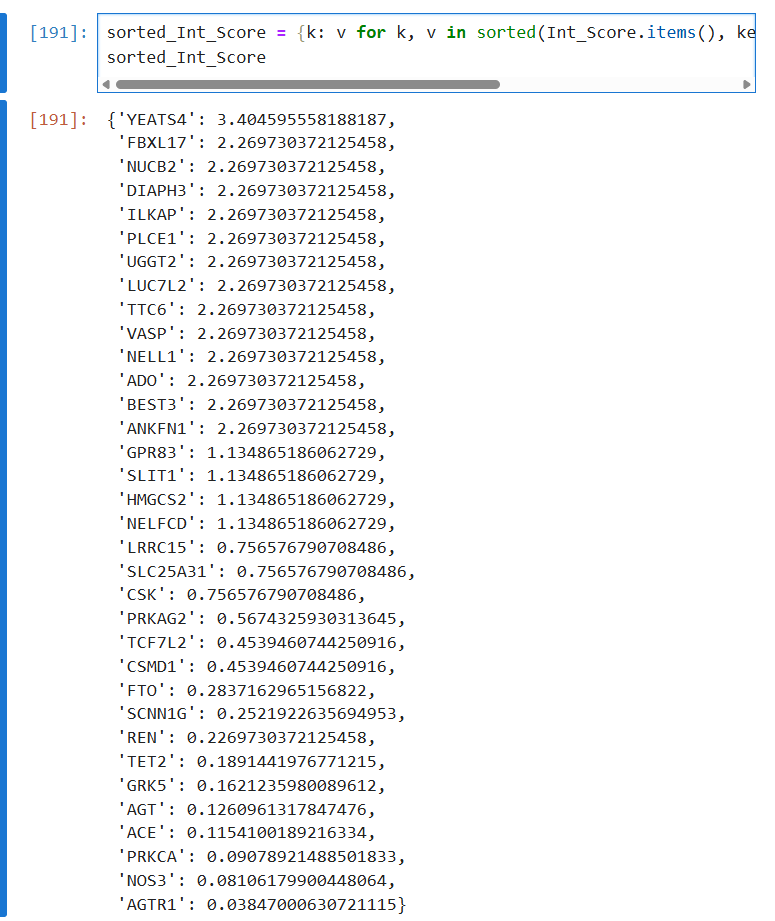

```r
display_png(file = "Interaction_Scores.png")   # PNG only
```

The figure above shows the dictionary made of all the genes associated with HCLZ interaction. The interaction scores of each gene to HCLZ were extracted. Interaction Scores is a ranking system to determine the strength of the interaction of a gene and drug. The gene score is based on an evidence score (publication count + score count) as well as relative drug specificity (the ratio of average known gene partners for all drugs to known gene partners for drug d) and relative gene specificity (average known drug partners for all genes to known drug partners for gene g). Since the query was a drug, the query scores of these drugs were calculated based on evidence score: queried drug interacting with gene g and relative gene specificity.

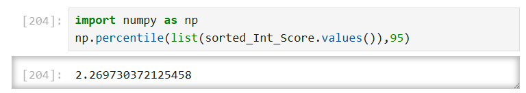

```r
display_png(file = "95th_percentile.png")
```

### Transcriptomics

Data obtained from the following paper:

Wang S, Hu Y, Wang Y, Song Y, Liang D, Yin J, Li Y, Yang W, Zhang D. Joint Analysis of Multiple Omics to Describe the Biological Characteristics of Resistant Hypertension. J Clin Hypertens (Greenwich). 2025 Jan;27(1):e14961. doi: 10.1111/jch.14961. Epub 2024 Dec 24. PMID: 39716980; PMCID: PMC11774085.

NCBI GEO Acession: GSE236442

Since NCBI GEO only provided FPKMs (Fragments per kilobase of exon per million mapped fragments), I turned to SRA (Sequence Read Archive) to obtain the SRA accession numbers for each of the 30 samples and downloaded the raw paired end fastq files onto the HPC. This is because DESeq2 requires raw read counts and not FPKMs because the comparison across samples will not be an accurate representation of differential gene expression. FPKMs are used to report gene expression and normalized for seqeuncing depth and gene length. Since normalization was performed this makes the data unfit for DESeq2 analysis because DESeq2 expects raw counts as inputs. The program performs its own normalization to account for the varying biases, thus a raw count was necessary to generate for this study.

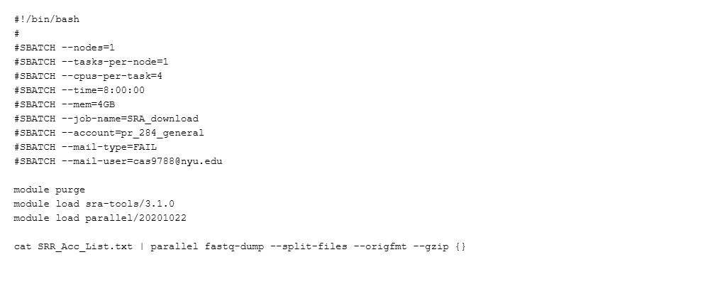

```r
display_png(file = "SRA_download.png")
```

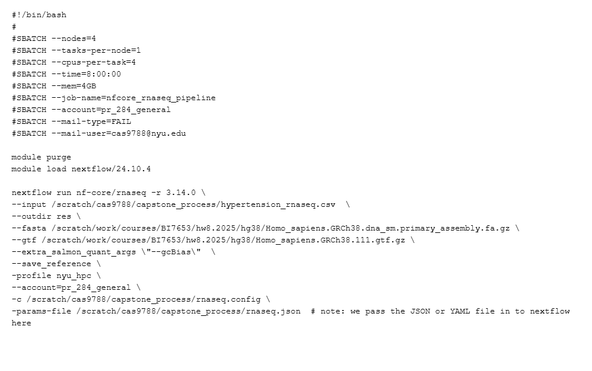

```r
display_png(file = "nfcore_rnaseq_pipeline.png")
```

Using the nextflow manager, the nfcore/rnaseq pipeline was accessed to begin the process of inferring standedness(the library prep was not included in the paper). Strandedness refers to the RNA-seq library preparation where two methods are commonly employed, either stranded or unstranded. Stranded maintains the orientation of the transcript, preserving information of whether the transcript came from the sense or antisense strand of the DNA. Unstranded library prep omits this information, making it unsuitable for certain studies that require such specificity. Salmon is an aligner offered by the pipeline which has a feature that can infer strandedness.

Furthermore, other tools the pipeline utilizes are: FASTQC for quality control, Trim Galore! for adapter and quality trimming, BBSplit for removal of genome contaminants, and SortMERNA to remove any ribosomal RNA. The aligner used was the pseudo-aligner Salmon for alignment and quantification. Salmon was chosen Salmon over traditional aligners like STAR or HiSAT2 is because it is computationally efficient since it aims to identify the gene or transcript rather than the mapping. This method is also ideal for the DESeq2 pipeline and is designed for quantification. The original paper used a HiSat2 genome aligner to account for variants and feature counts to account for splice junctions. I've opted to use Salmon because it handles multi-mapping reads more effectively and ultimately is a better tool for transcript quanitification.

The reference genome is a Homo Sapiens GRCH38 DNA primary assembly fasta from ENSEMBL. The gene annotation is Homo Sapiens GRCh38 gtf, also downloaded from ENSEMBL. The parameters included --gc Bias to correct for gc bias that could effect the count data. As mentioned previously, library prep was not included in the paper so auto inference was selected in the csv with the sample names and fasta locations. Through looking at the outputs of the data it was found to be an inward unstranded prep, which means that the orientation of the strand is lost, however with the inference feature of Salmon this will take this into account making the gene expression counts more reliable.

### Differntial Gene Expression analysis

After obtaining the tsv file generated from the pipeline, a deseq2 matrix was created and used for downstream analysis. This included performing PCA and Differential Gene analysis using the DESeq() function. The comparison was done on Normal vs Hypertensive, Normal vs Resistant Hypertensive, and Hypertensive vs Resistant Hypertensive (with the first in each group being the reference). Then significant genes were isolated based on adjusting the p-values using Benjamini and Hochberg's False Discovery Rate (FDR). FDR is a statistical method to account for multiple hypothesis testing. With multiple hypothesis testing, there is a rate of false positives that can inaccurately determine genes as significant. FDR attempts to account for the large amount of false positives due to multiple hypothesis testing by calculating an adjusted p-value that ensures no more than a certain percentage is false positives. Significant genes were described as having an adjusted p-value of <= 0.05 and |log2(foldchange)| >= 0.

Significant genes then were annotated using GO terms and compared to each group. The high interaction score genes from the DGIdb analysis will be used to see if there is differential expression occuring in the diseased groups. Furthermore, the other expressed genes will be queried into the GraphQL DGIdb to see other gene-drug interactions.

### Tools used

1. SRA tools, to retrieve sequencing fastq files.

module used: sra-tools/3.1.0

2. nextflow, for parallel computational efficiency

module used: nextflow/24.10.4

3. nf-core/rnaseq, rna seq analysis pipeline

module used: nf-core/rnaseq/3.14.0

4. Salmon, psuedo-aligner equipped for transcript quanitfication

module used: salmon/1.10.1

5. Tximport, quantify transcripts

module used: bioconductor-tximeta/1.12.0

6. DESeq2, differential gene expression analysis

package used: DESeq2/1.46.0

## Results and Discussion

```r
#converting to log to conduct PCA
rld <- rlog(dds)
```

```
rlog() may take a few minutes with 30 or more samples,
vst() is a much faster transformation
```

```
using ntop=500 top features by variance
```

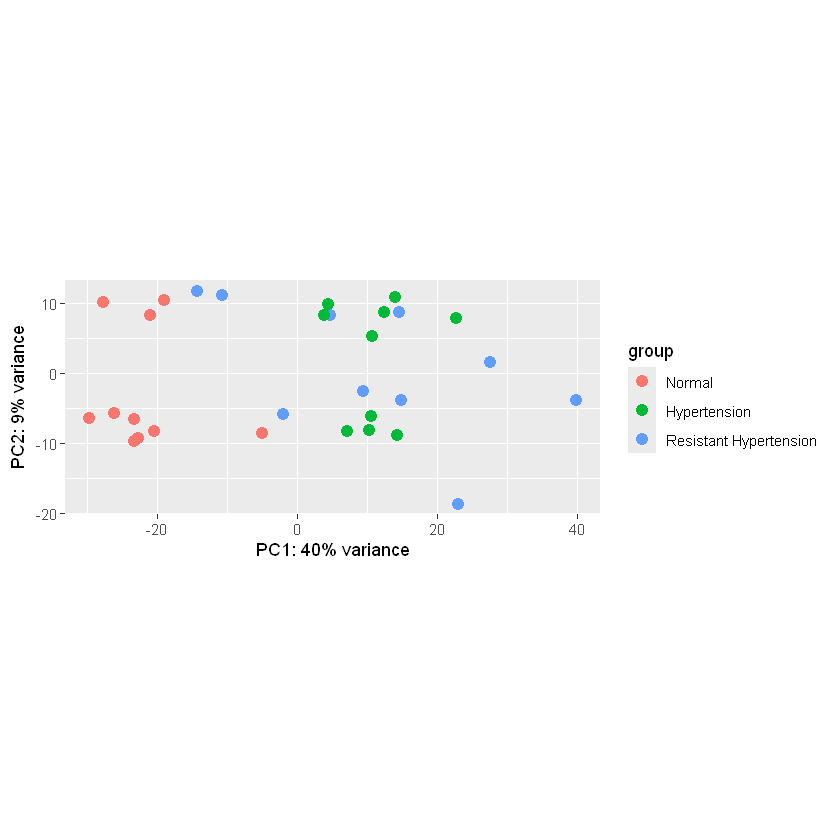

```r
plotPCA(rld)
```

After normalization and estimation of size factors,PCA plot was implemented to observe the overall groupings of the data.The first principal component contributes to the most variation depicted by the x-axis. Furthermore the normal and hypertensive group are nicely seperated by the x-axis which shows a difference in expression profile from this reduction of dimensionality. Interestingly, the resistant hypertensive group shows a large spread in the x axis, but still somewhat distinct from the normal group. Within the Resistant Hypertensive group there seems to be a large amount of variance in both axes which could be contributed to the variability in the disease. While the hypertensive group shows more tightness in the clustering, the resistant large spread could be a result of other factors like other diseases since resistant hypertension patients are said to have other diseases. Also most notably in the resistant hypertensive group there are some outliers that show similarity to some normal groups.

### Normal vs Hypertensive Analysis

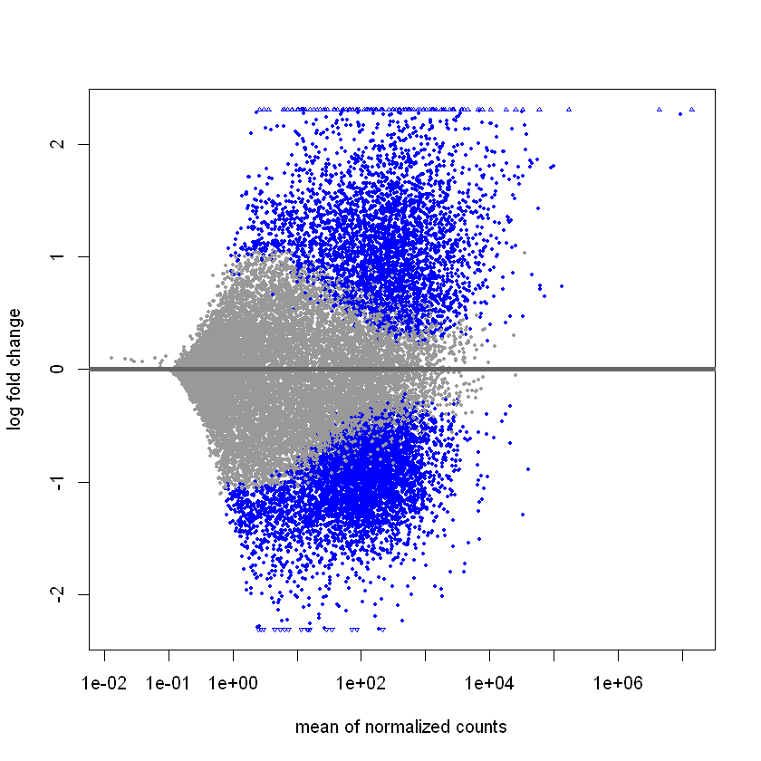

```r
plotMA(res.lfcShrink)
```

The above plot was made using plotMA() on the dds object comparing the normal group to the hypertensive group, where the normal is the reference. From here we see a substantial amount of high count genes with a large fold change.

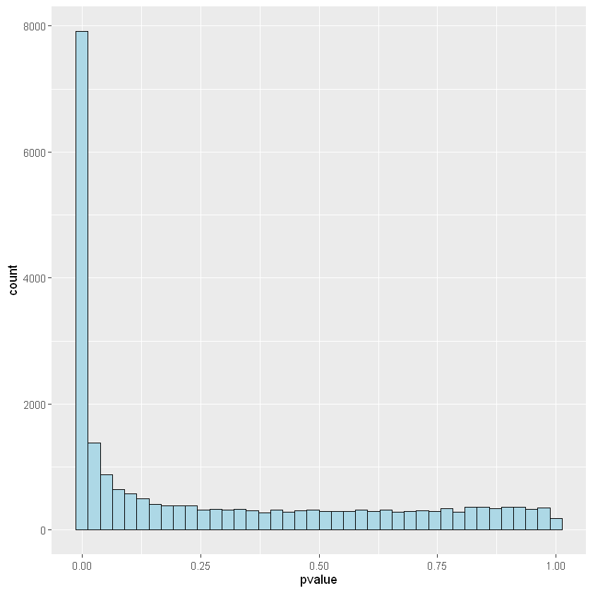

```r
res.lfcShrink %>%
  as_tibble() %>% # coerce to tibble
  ggplot(aes(pvalue)) +
  geom_histogram(fill="light blue",color='black',bins = 40)
```

Distribution of p-values to counts. In lower p-value range there is some differential expression going on between normal and hypertensive. This is further confidence that there are differences between the groups.

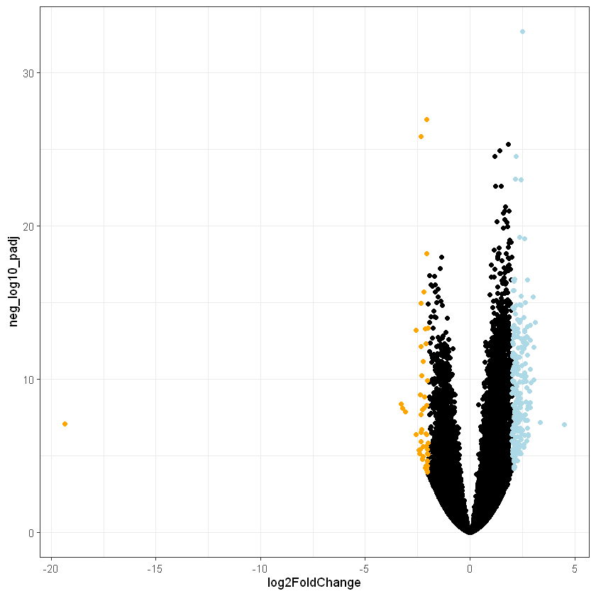

```r
res.lfcShrink.tbl_df %>% # pipe the data.frame (tibble) to mutate to add a column named "neg_log10_padj" with negative log10 adjusted p-values
  mutate(neg_log10_padj = -1*log10(padj)) %>% # pipe the modified data.frame (tibble) to first (data) argument of ggplot
  ggplot(aes(x = log2FoldChange, y = neg_log10_padj)) + # define which columns (variables) to plot on x and y axes with aes()
  geom_point(colr = 'gray') + # add gray points
  geom_point( data = ~.x %>% filter(log2FoldChange < -2 & neg_log10_padj > 2), color = 'orange') + # add a second layer of orange points on subset of data
  geom_point( data = ~.x %>% filter(log2FoldChange > 2 & neg_log10_padj > 2), color = 'light blue') + # add a third layer of blue points on subset of data
  theme_bw()
```

Volcanoe plot above shows significant amount of upregulated genes. Less amount of downregulation, with one gene having a very large fold change of -20.

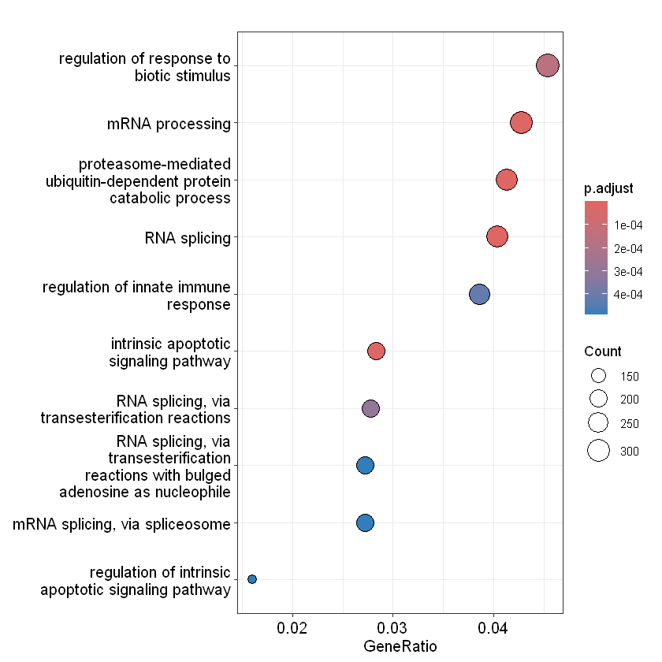

```r
dotplot(bp.enrichResult, showCategory=10)
```

Using clusterprofiler package in the Biocmanager, the significant genes from the comparison were analyzed and enriched for any significant gene ratios of biological processes. It seems a large amount of the genes have some affiliation with RNA regulation and immune response.

### Normal vs Resistant Hypertensive Analysis

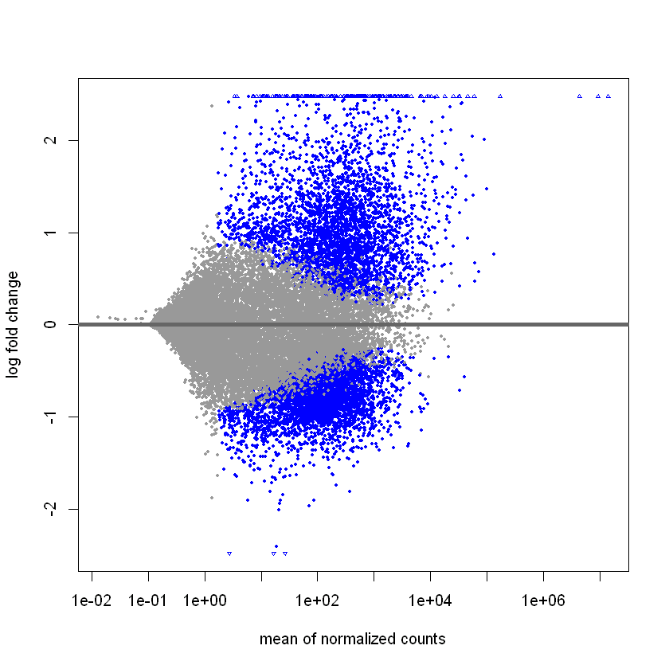

```r
plotMA(res.lfcShrink)
```

The MA plot above represents the comparison of the log fold change of the normal compared to the resistant hypertensive group. This ma plot illustrates signigicant amount of genes with more of an emphasis on upregulated genes than the previous comparison.

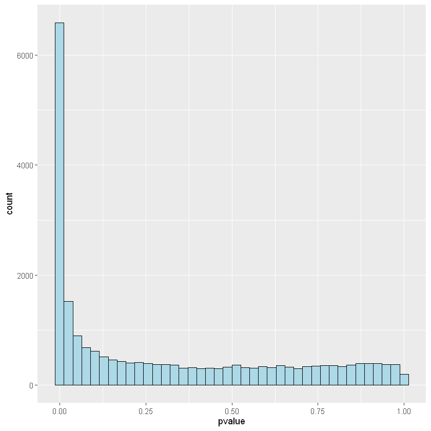

```r
res.lfcShrink %>%
  as_tibble() %>% # coerce to tibble
  ggplot(aes(pvalue)) +
  geom_histogram(fill="light blue",color='black',bins = 40)
```

Similarly, observe a negative binomial distribution of the counts and pvalues. There is a substantial amount of significant genes seperating these two phenotypes.

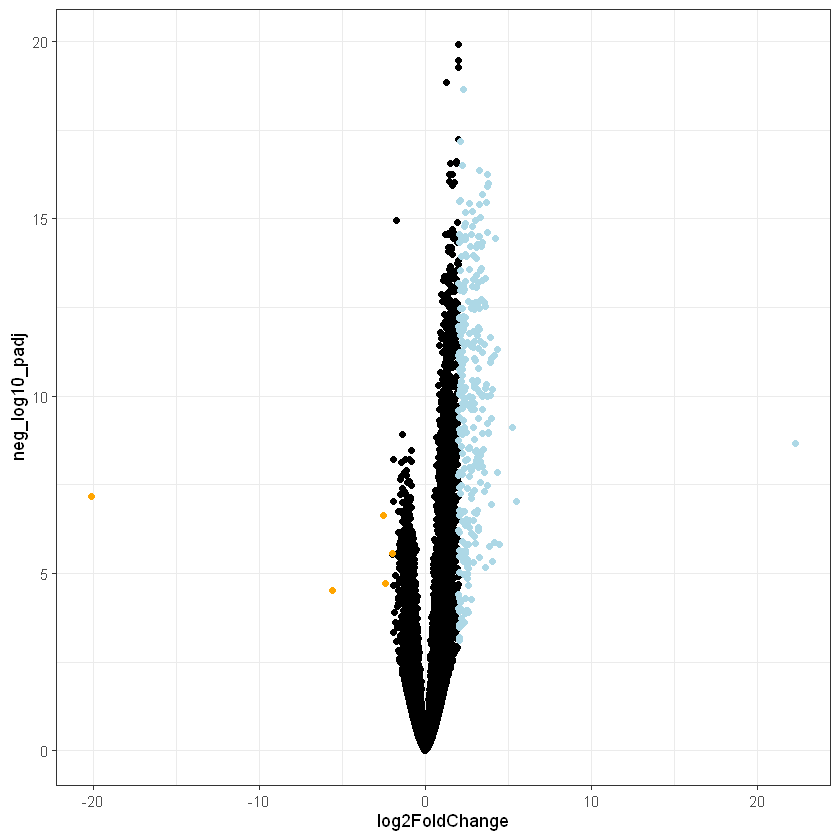

```r
res.lfcShrink.tbl_df %>% # pipe the data.frame (tibble) to mutate to add a column named "neg_log10_padj" with negative log10 adjusted p-values
  mutate(neg_log10_padj = -1*log10(padj)) %>% # pipe the modified data.frame (tibble) to first (data) argument of ggplot
  ggplot(aes(x = log2FoldChange, y = neg_log10_padj)) + # define which columns (variables) to plot on x and y axes with aes()
  geom_point(colr = 'gray') + # add gray points
  geom_point( data = ~.x %>% filter(log2FoldChange < -2 & neg_log10_padj > 2), color = 'orange') + # add a second layer of orange points on subset of data
  geom_point( data = ~.x %>% filter(log2FoldChange > 2 & neg_log10_padj > 2), color = 'light blue') + # add a third layer of blue points on subset of data
  theme_bw()
```

17006

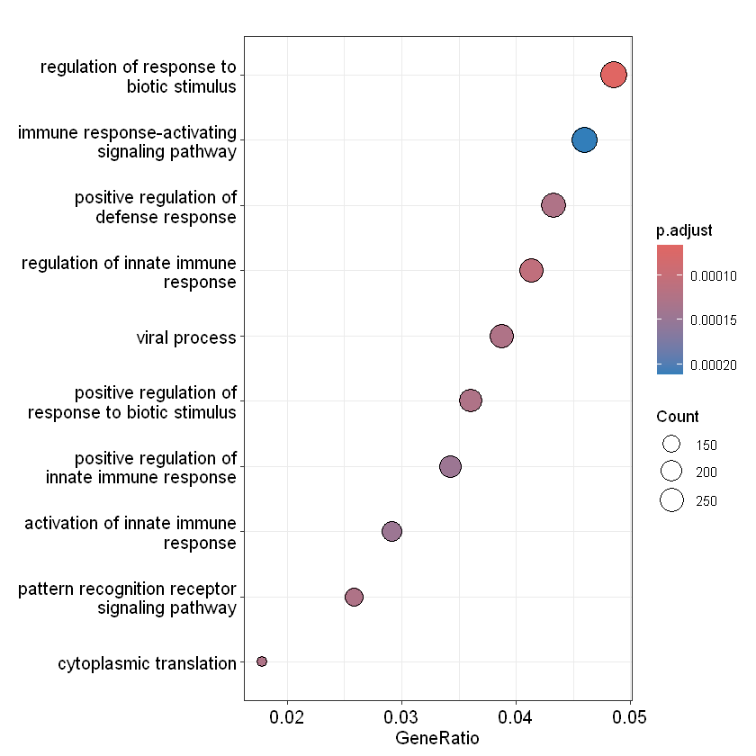

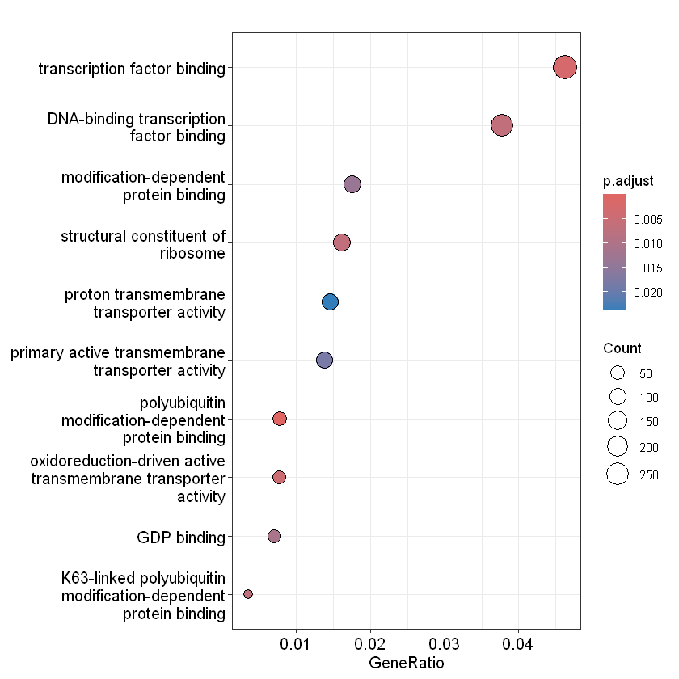

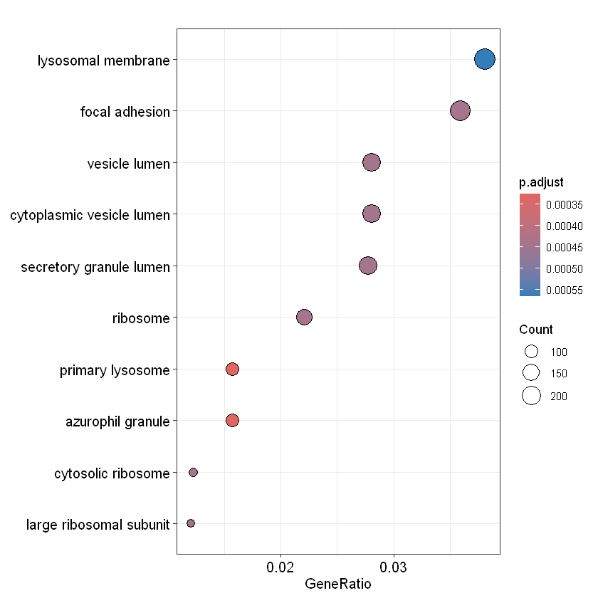

```r
universe_genes.v <- res.lfcShrink.tbl_df %>%
  filter(!is.na(padj)) %>% # here we preserve any gene that does not have missing data after independent filtering in the results object
  pull(feature_id)

length(universe_genes.v)

bp.enrichResult <- enrichGO(gene = significant_genes.v, # specifify the significant set of genes
         OrgDb = org.Hs.eg.db,
         keyType = "ENSEMBL",
         ont = "BP", # select Biological Process ontology. Molecular Function (MF) and Cellular Compartment (CC) may also be interesting
         pAdjustMethod = "BH",
         universe = universe_genes.v) # specify the background set of genes
dotplot(bp.enrichResult, showCategory=10)
mf.enrichResult <- enrichGO(gene = significant_genes.v, # specifify the significant set of genes
         OrgDb = org.Hs.eg.db,
         keyType = "ENSEMBL",
         ont = "MF", # select Biological Process ontology. Molecular Function (MF) and Cellular Compartment (CC) may also be interesting
         pAdjustMethod = "BH",
         universe = universe_genes.v) # specify the background set of genes
dotplot(mf.enrichResult, showCategory=10)
cc.enrichResult <- enrichGO(gene = significant_genes.v, # specifify the significant set of genes
         OrgDb = org.Hs.eg.db,
         keyType = "ENSEMBL",
         ont = "CC", # select Biological Process ontology. Molecular Function (MF) and Cellular Compartment (CC) may also be interesting
         pAdjustMethod = "BH",
         universe = universe_genes.v) # specify the background set of genes
dotplot(cc.enrichResult, showCategory=10)
```

The top GO annotation is biological process enrichment and shows a large amount of immune related processes. The samples are themselves human blood which contains a variety of cell types like red blood cells, white blood cells, etc. Since Resistant hypertensives often have association to other diseases this significant amount of genes being differentially expressed could be a result of other factors not relating to hypertension and the causes of it.

### Hypertensive vs Resistant Hypertensive Analysis

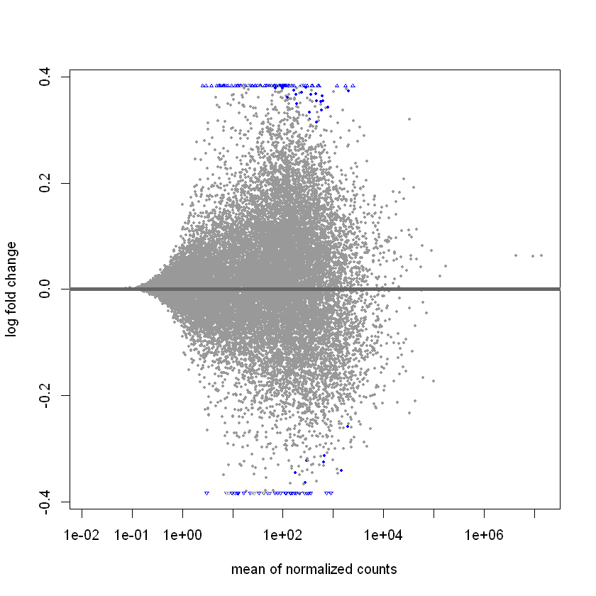

```r
plotMA(res.lfcShrink)
```

The above MA plot is the comparison of the hypertensive groups as the reference and the resistant hypertensive. As was seen in the PCA plot these two groups showed distinct similarities and thus would be expected to have fewer differentially expressed genes.

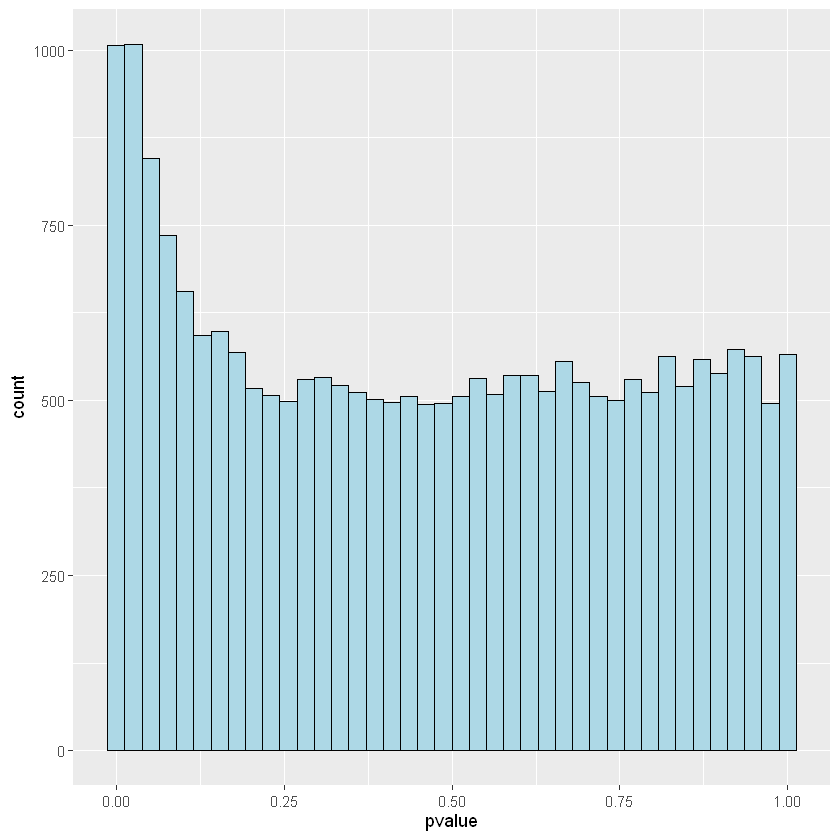

```r
res.lfcShrink %>%
  as_tibble() %>% # coerce to tibble
  ggplot(aes(pvalue)) +
  geom_histogram(fill="light blue",color='black',bins = 40)
```

As expected see a uniform distribution in counts for most p-values however there is a slight increase of counts.

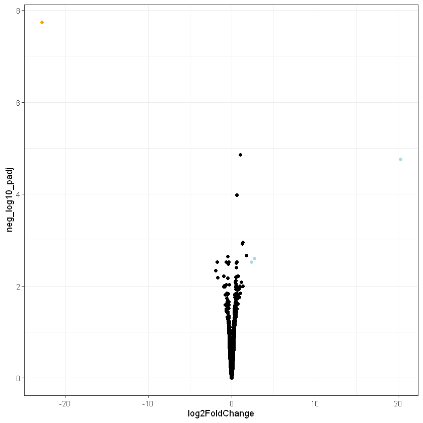

```r
res.lfcShrink.tbl_df %>% # pipe the data.frame (tibble) to mutate to add a column named "neg_log10_padj" with negative log10 adjusted p-values
  mutate(neg_log10_padj = -1*log10(padj)) %>% # pipe the modified data.frame (tibble) to first (data) argument of ggplot
  ggplot(aes(x = log2FoldChange, y = neg_log10_padj)) + # define which columns (variables) to plot on x and y axes with aes()
  geom_point(colr = 'gray') + # add gray points
  geom_point( data = ~.x %>% filter(log2FoldChange < -2 & neg_log10_padj > 2), color = 'orange') + # add a second layer of orange points on subset of data
  geom_point( data = ~.x %>% filter(log2FoldChange > 2 & neg_log10_padj > 2), color = 'light blue') + # add a third layer of blue points on subset of data
  theme_bw()
```

16125

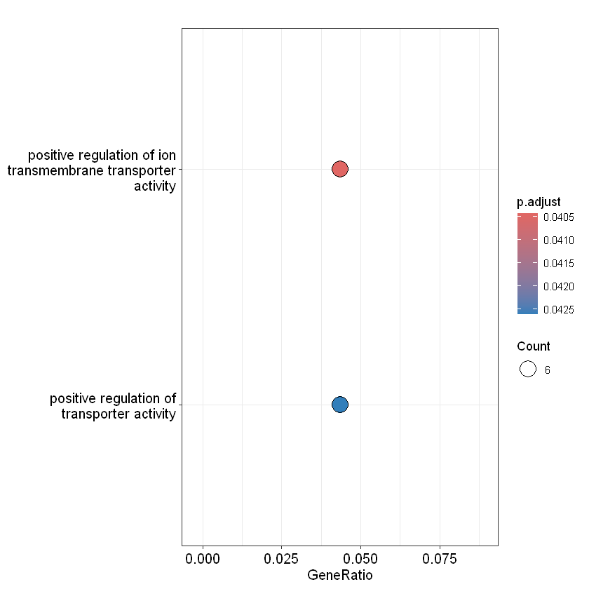

[output not shown]

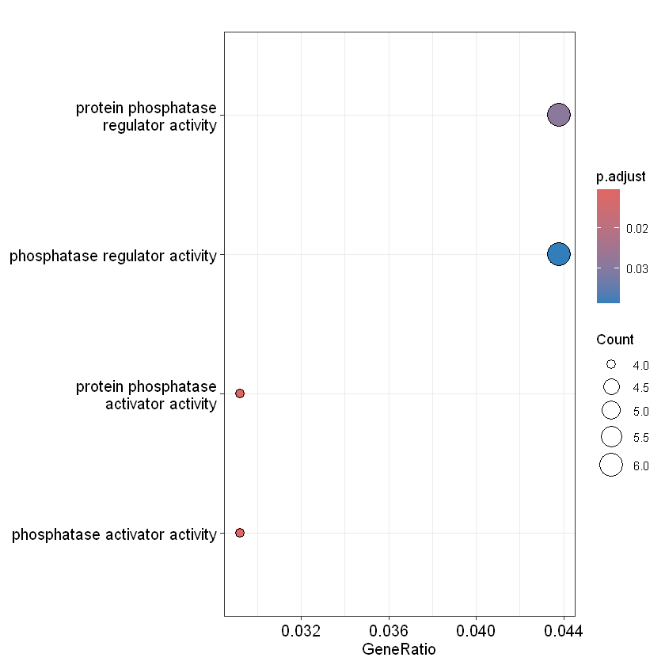

```r
universe_genes.v <- res.lfcShrink.tbl_df %>%
  filter(!is.na(padj)) %>% # here we preserve any gene that does not have missing data after independent filtering in the results object
  pull(feature_id)

length(universe_genes.v)

bp.enrichResult <- enrichGO(gene = significant_genes.v, # specifify the significant set of genes
         OrgDb = org.Hs.eg.db,
         keyType = "ENSEMBL",
         ont = "BP", # select Biological Process ontology. Molecular Function (MF) and Cellular Compartment (CC) may also be interesting
         pAdjustMethod = "BH",
         universe = universe_genes.v) # specify the background set of genes
dotplot(bp.enrichResult, showCategory=10)
mf.enrichResult <- enrichGO(gene = significant_genes.v, # specifify the significant set of genes
         OrgDb = org.Hs.eg.db,
         keyType = "ENSEMBL",
         ont = "MF", # select Biological Process ontology. Molecular Function (MF) and Cellular Compartment (CC) may also be interesting
         pAdjustMethod = "BH",
         universe = universe_genes.v) # specify the background set of genes
dotplot(mf.enrichResult, showCategory=10)
cc.enrichResult <- enrichGO(gene = significant_genes.v, # specifify the significant set of genes
         OrgDb = org.Hs.eg.db,
         keyType = "ENSEMBL",
         ont = "CC", # select Biological Process ontology. Molecular Function (MF) and Cellular Compartment (CC) may also be interesting
         pAdjustMethod = "BH",
         universe = universe_genes.v) # specify the background set of genes
dotplot(cc.enrichResult, showCategory=10)
```

### Differential Genes

LOC102724594 is down regulated in the resistant hypertensives which is a possible gene that causes the difference between a normal and hypertensive phenotype. Furthermore in the resistant hypertension the gene H2AC19 is upregulated than the normal.

```r
sig_genes_N_EH %>% filter(SYMBOL=="H2AC19") # This gene not observed as differentially expressed in hypertensive group
```

A tibble: 0 × 7

| feature_id | baseMean | log2FoldChange | lfcSE | pvalue | padj | SYMBOL |
| --- | --- | --- | --- | --- | --- | --- |
| <chr> | <dbl> | <dbl> | <dbl> | <dbl> | <dbl> | <chr> |

H2AC19 is not found to be differentially expressed between the normal and hypertensive group. This gene codes for the protein H2A clustered histone 19. This is another regulatory protein that alters gene expression. This gene is found in bone marrow cells as well as kidney cells.

```r
significant_genes_EH_RH %>% filter(SYMBOL=="LOC102724594")
```

A tibble: 0 × 7

| feature_id | baseMean | log2FoldChange | lfcSE | pvalue | padj | SYMBOL |
| --- | --- | --- | --- | --- | --- | --- |
| <chr> | <dbl> | <dbl> | <dbl> | <dbl> | <dbl> | <chr> |

Notably, we see H2AC19 is upregulated in the resistant hypertensive group making this a gene that adds to the difference between resistant and hypertensive. There is also a down regulation in the Resistant Hypertensive group which is found to be a novel transcript. Furthermore, this expression is downregulated compared to the normal but at a lower magnitude. Gene LOC102724594 is a similarly expressed gene in the disease type.

The list of genes with high interactions retrieved from DGIdb were referenced to see if there is any significant differential expression between the hypertensive and resistant hypertensive group that can give a biological insight as to why the Resistant Hypertensive groups do not respond to HCLZ.

```r
dgib <- list('YEATS4','FBXL17','NUCB2','DIAPH3','ILKAP','PLCE1','UGGT2','LUC7L2','TTC6','VASP','NELL1','ADO','BEST3','ANKFN1') %>% unlist()
dgib
```

1. 'YEATS4'

2. 'FBXL17'

3. 'NUCB2'

4. 'DIAPH3'

5. 'ILKAP'

6. 'PLCE1'

7. 'UGGT2'

8. 'LUC7L2'

9. 'TTC6'

10. 'VASP'

11. 'NELL1'

12. 'ADO'

13. 'BEST3'

14. 'ANKFN1'

```r
dgib_EH_RH <- significant_genes_EH_RH[significant_genes_EH_RH$SYMBOL %in% dgib, ]
dgib_EH_RH
```

A tibble: 0 × 7

| feature_id | baseMean | log2FoldChange | lfcSE | pvalue | padj | SYMBOL |
| --- | --- | --- | --- | --- | --- | --- |
| <chr> | <dbl> | <dbl> | <dbl> | <dbl> | <dbl> | <chr> |

Highly correlated drug gene interactions show no differential expression between hypertensive and resistant hypertension groups. Therefore, the genes found through the DGIdb query do not show a genomic reasoning for being resistant to hypertension medication.

```r
dgib_N_EH <- sig_genes_N_EH[sig_genes_N_EH$SYMBOL %in% dgib, ]
dgib_N_EH
```

A tibble: 7 × 7

| feature_id <chr> | baseMean <dbl> | log2FoldChange <dbl> | lfcSE <dbl> | pvalue <dbl> | padj <dbl> | SYMBOL <chr> |
| --- | --- | --- | --- | --- | --- | --- |
| ENSG00000146963 | 278.179881 | -0.8367215 | 0.1482875 | 1.076455e-08 | 1.238245e-07 | LUC7L2 |
| ENSG00000138193 | 5.203784 | -1.6024322 | 0.5281340 | 2.097698e-04 | 8.245709e-04 | PLCE1 |
| ENSG00000125753 | 5520.685638 | 0.6733130 | 0.1931078 | 3.611781e-04 | 1.334789e-03 | VASP |
| ENSG00000102595 | 3.939647 | -1.2672532 | 0.5567672 | 4.297681e-03 | 1.193075e-02 | UGGT2 |
| ENSG00000181915 | 93.597688 | -0.6143235 | 0.2379432 | 7.505345e-03 | 1.951512e-02 | ADO |
| ENSG00000145743 | 84.077023 | -0.7851758 | 0.3293094 | 1.061794e-02 | 2.633849e-02 | FBXL17 |
| ENSG00000070081 | 88.230043 | -0.6548174 | 0.2715501 | 1.157514e-02 | 2.842731e-02 | NUCB2 |

```r
dgib_N_RH <- sig_genes_N_RH[sig_genes_N_RH$SYMBOL %in% dgib, ]
dgib_N_RH
```

A tibble: 5 × 7

| feature_id <chr> | baseMean <dbl> | log2FoldChange <dbl> | lfcSE <dbl> | pvalue <dbl> | padj <dbl> | SYMBOL <chr> |
| --- | --- | --- | --- | --- | --- | --- |
| ENSG00000127337 | 22.94487 | -1.0616294 | 0.3693361 | 8.766294e-04 | 0.0035318549 | YEATS4 |
| ENSG00000145743 | 84.07702 | -1.0166652 | 0.3263382 | 4.945261e-04 | 0.0021742271 | FBXL17 |
| ENSG00000070081 | 88.23004 | -0.9965283 | 0.2729939 | 8.141957e-05 | 0.0004551680 | NUCB2 |
| ENSG00000146963 | 278.17988 | -0.6618073 | 0.1490702 | 5.779722e-06 | 0.0000455046 | LUC7L2 |
| ENSG00000125753 | 5520.68564 | 0.4335302 | 0.1910142 | 1.878412e-02 | 0.0456216456 | VASP |

Above shows the differentially expressed genes that were from DGIdb query, comparing the diseased groups to the normal reference. Although it is unclear from the meta data whether the hypertensive group individuals use HCLZ, the resistant hypertensive all were taking HCLZ. However the effect of this interaction can't be confirmed since the resistant group takes multiple different drugs at a time.

Returning back to the GraphQL DGIdb , the three genes that showed a log fold change of above 20 were queried, but because these genes are not ideal candidates for drug investigation there was no information. However taking the top 20 significant genes based on adjusted p-value, the list was queried and large drug-gene interactions were found, which could be possible potential novel treatments for the effects of hypertension.

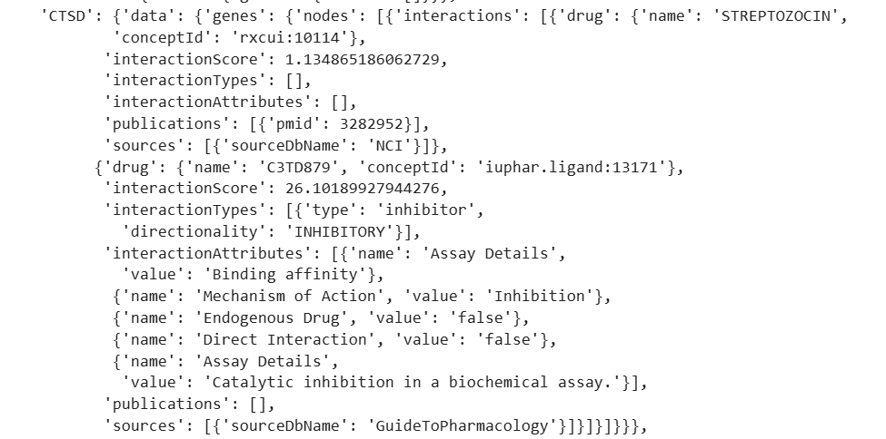

```r
display_png(file = "CTSD.png")
```

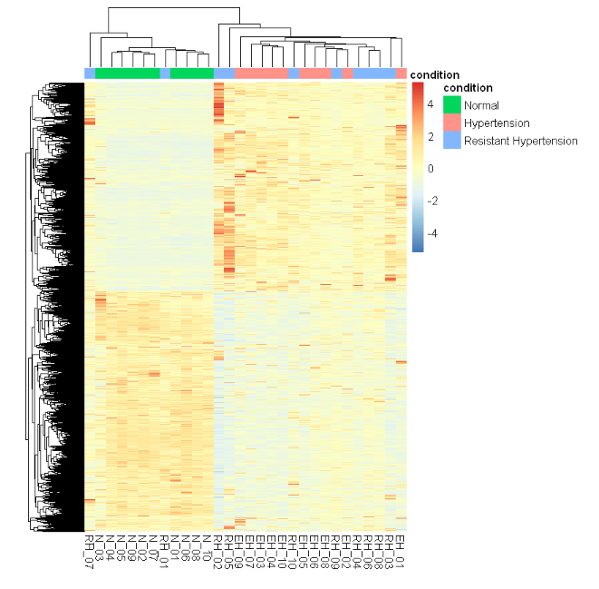

```r
display_png(file = "Heatmap.png")
```

The above heatmap depicts the cluster of closely related genes and their expression across all samples. In addition, clustering was performed on the samples to determine how closely related individual samples are. Hypertension and resistant hypertension are closely related further emphasizing that other factors are at play for the genetic basis of resistant hypertension. Interestingly, we see two resistant samples in a cluster more closely related to the normal expression pattern. These could be potential outliers or add a layer of complexity to the disease that can be elucidated from further investigation.